# 2 Linear Regression

*Description of the work for this week*

The data is based on an International survey of Approaches to Learning. It was gathered in 2014-2015 in Finland by Kimmo Vehkalahti I have prepared a subdataset to for this analysis. It consists of **166 respondent and 7 variables.** Background variables include age and gender of the students. Measures include Points (overall), Attitude (towards statistics) and three measures of learning styles: Deep, Strategic and Surface. [see more](https://www.mv.helsinki.fi/home/kvehkala/JYTmooc/JYTOPKYS2-meta.txt)

## 1. Read data

```r
# Read data
library(dplyr)
lr14 <- read.csv("learning2014.csv")
lr14 <- select(lr14, -1)
head(lr14)
```

```
##   gender Age Attitude Points  stra     surf     deep
## 1      F  53       37     25 3.375 2.583333 3.583333
## 2      M  55       31     12 2.750 3.166667 2.916667
## 3      F  49       25     24 3.625 2.250000 3.500000
## 4      M  53       35     10 3.125 2.250000 3.500000
## 5      M  49       37     22 3.625 2.833333 3.666667
## 6      F  38       38     21 3.625 2.416667 4.750000
```

```r
str(lr14)
```

```
## 'data.frame':    166 obs. of  7 variables:
##  $ gender  : Factor w/ 2 levels "F","M": 1 2 1 2 2 1 2 1 2 1 ...
##  $ Age     : int  53 55 49 53 49 38 50 37 37 42 ...
##  $ Attitude: int  37 31 25 35 37 38 35 29 38 21 ...
##  $ Points  : int  25 12 24 10 22 21 21 31 24 26 ...
##  $ stra    : num  3.38 2.75 3.62 3.12 3.62 ...
##  $ surf    : num  2.58 3.17 2.25 2.25 2.83 ...
##  $ deep    : num  3.58 2.92 3.5 3.5 3.67 ...
```

```r
dim(lr14)
```

```
## [1] 166   7
```

## 2 Explore the data

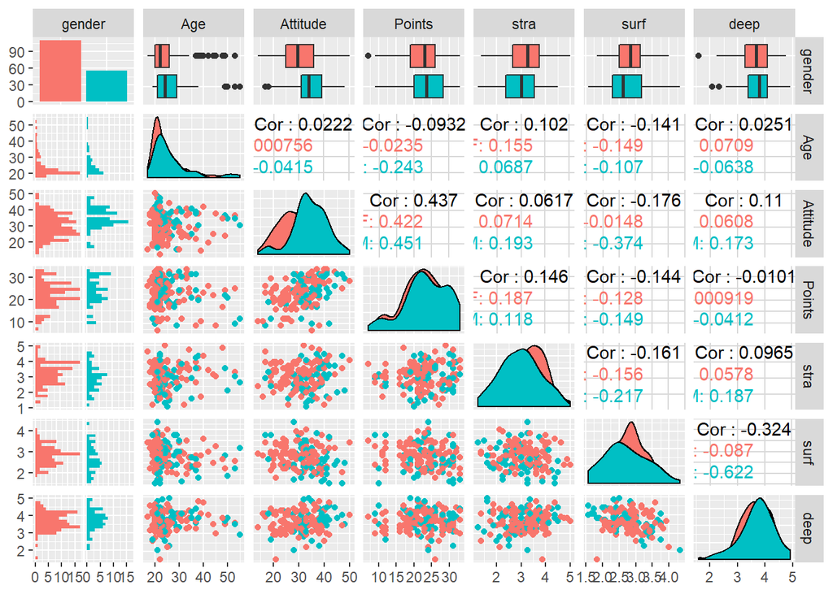

```r
# EDA
library(ggplot2)
library(GGally)
# ggpairs for good overview
p3 = ggpairs(lr14, aes(col=gender), lower = list(combo = wrap("facethist", bins = 20)))
p3
```

**Some observations:**

- The majority of respondents are females (red color) and under 30-year-olds (bar chart).
- The variance of Points is greater among women, although the mean is quite the same (boxplot).
- The highest correlations are between Attitude and Points (0.437) & surf and deep (-0.324) (correlations).

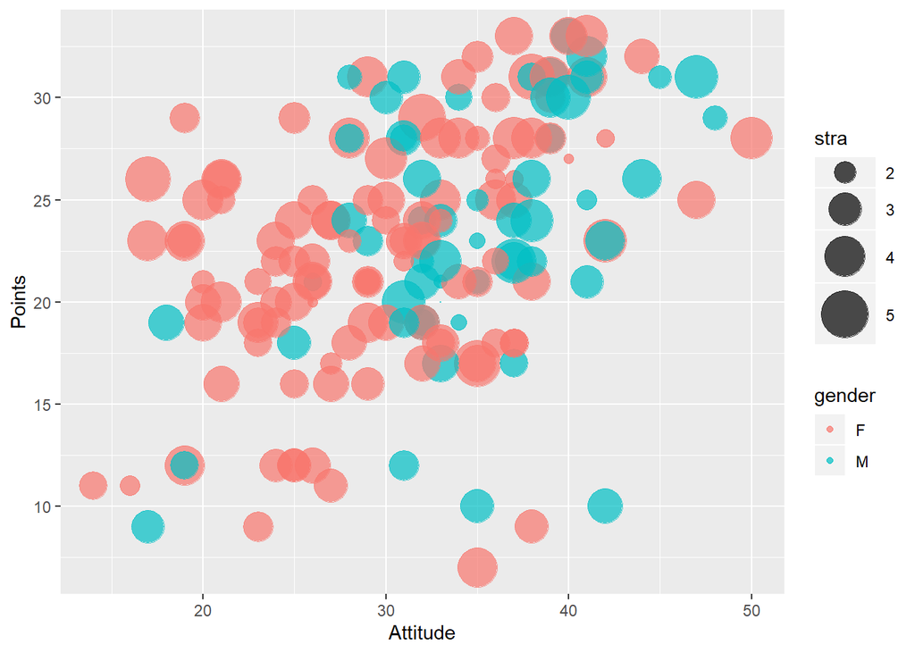

```r
# Bubble chart
p4 = ggplot(lr14, aes(x=Attitude, y=Points, size=stra, col=gender)) + geom_point(alpha=0.7) + scale_size(range = c(.1, 12), name="stra")
p4
```

**Some observations:**